# Práctica 4. Manejo de Datos

Tratamiento de Datos, Grado en Ciencia de Datos - UV

Carlos Santiago Martinez Torres

2025-04-02

# Introducción y objetivos.

El objetivo de esta práctica es manejar data frames estructurados (variables en columnas, muestras en filas) con **tidyR** de una manera eficiente y sencilla utilizando la librería **DPLYR**. Esta librería fue desarrollada por Hadley Wickham (el creador de tidyR) con funciones programadas en C++ de manera óptima. Cuando hablamos de manejar data frames nos referimos a realizar operaciones sobre las muestras y sobre las variables tales como:

1. Seleccionar muestras de un data frame en base a algún tipo de criterio.
2. Seleccionar variables que cumplan alguna condición.
3. Ordenar las muestras de un data frame.
4. Unir varios data frames.
5. Crear nuevas variables a partir de las variables existentes.
6. Agrupar muestras que cumplan algún criterio para realizar cálculos estadísticos.

Para llevar a cabo estas operaciones **DPLYR** proporciona una serie de funciones que enumeramos a continuación:

- `select()`. Permite seleccionar un subconjunto de las variables (columnas) del data frame.
- `filter()`. Esta función, como su propio nombre indica, permite filtrar las muestras (filas) de un data frame en base a algún criterio.
- `group_by()`. Esta función crea grupos de muestras a partir de las categorías de una variable.
- `summarise()`. Esta función facilita el cálculo de parámetros estadísticos de las variables de un data frame.
- `arrange()`. Permite reordenar las muestras de un data frame.
- `XXX_join()`. Las funciones de la familia *XXX_join* permiten combinar data frames.
- `rename()`. Esta función permite renombrar variables de un data frame.
- `mutate()`. Esta función permite añadir nuevas variables (columnas) a partir de la transformación de columnas ya existentes.
- `%>%` Es el operador *pipe* que permite concatenar funciones.

En clase de teoría te han explicado cómo utilizar estas funciones y ya has trabajado con ellas, así que vamos a ver como te desenvuelves con **DPLYR**.

# Ejercicios

Vamos a cargar el conjunto de datos `VuelosNY.Rdata` que contiene dos data frames: `flights` y `planes`.

## Ejercicio 1

Muestra las primeras muestras de ambos data frames para hacerte una idea de las variables que contienen. ¿Qué diferencia existe entre la información mostrada en ambos data frames?

# Información sobre el df de vuelos

```r
head(flights)
```

```
  year month day dep_time sched_dep_time dep_delay arr_time sched_arr_time arr_delay carrier flight
1 2013     1   1      517            515         2      830            819        11      UA   1545
2 2013     1   1      533            529         4      850            830        20      UA   1714
3 2013     1   1      542            540         2      923            850        33      AA   1141
4 2013     1   1      544            545        -1     1004           1022       -18      B6    725
5 2013     1   1      554            600        -6      812            837       -25      DL    461
6 2013     1   1      554            558        -4      740            728        12      UA   1696
  tailnum origin dest air_time distance hour minute  time_hour
1  N14228    EWR  IAH      227     1400    5     15 1357034400
2  N24211    LGA  IAH      227     1416    5     29 1357034400
3  N619AA    JFK  MIA      160     1089    5     40 1357034400
4  N804JB    JFK  BQN      183     1576    5     45 1357034400
5  N668DN    LGA  ATL      116      762    6      0 1357038000
6  N39463    EWR  ORD      150      719    5     58 1357034400
```

En el df tenemos información sobre la fecha en que se realizó el vuelo, los tiempos de vuelo, distancia, entre otros; es información general sobre el vuelo.

```r
head(planes)
```

```
  tailnum year                    type     manufacturer     model engines seats speed    engine
1  N10156 2004 Fixed wing multi engine          EMBRAER EMB-145XR       2    55    NA Turbo-fan
2  N102UW 1998 Fixed wing multi engine AIRBUS INDUSTRIE  A320-214       2   182    NA Turbo-fan
3  N103US 1999 Fixed wing multi engine AIRBUS INDUSTRIE  A320-214       2   182    NA Turbo-fan
4  N104UW 1999 Fixed wing multi engine AIRBUS INDUSTRIE  A320-214       2   182    NA Turbo-fan
5  N10575 2002 Fixed wing multi engine          EMBRAER EMB-145LR       2    55    NA Turbo-fan
6  N105UW 1999 Fixed wing multi engine AIRBUS INDUSTRIE  A320-214       2   182    NA Turbo-fan
```

En el df de planes, tenemos información sobre los aviones. El tipo, modelo, numero de motores, etc.

## Ejercicio 2

- Nota: Revisar el uso de la función `filter` vista en clase y tener en cuenta los operadores de comparación: igual ==, distinto !=, mayor >, mayor o igual >=, menor <, menor o igual <=.

```r
vector_douglas <- planes %>%
                  filter(grepl(c('DOUGLAS', 'MCDONNELL'), manufacturer, ignore.case = TRUE)) %>%
                  distinct(manufacturer) %>%
                  as.vector()
vector_douglas
```

```
$manufacturer
[1] "DOUGLAS"                       "MCDONNELL DOUGLAS"             "MCDONNELL DOUGLAS CORPORATION"
[4] "MCDONNELL DOUGLAS AIRCRAFT CO"
```

```r
planes.f <- planes %>%
            filter(!manufacturer %in% vector_douglas) %>%
            filter(seats>=90 & seats <=120)

planes.f$manufacturer[planes.f$manufacturer == 'AIRBUS'] <- 'AIRBUS COMP'

planes.f %>% filter(manufacturer=='AIRBUS') # Comprobamos que se hizo el cambio correcto
```

```
[1] tailnum      year         type         manufacturer model        engines      seats
[8] speed        engine
<0 rows> (o 0- extensión row.names)
```

## Ejercicio 3

Crea un data frame denominado `flights.f` que contenga los vuelos que involucren a los aviones presentes en el data frame `planes.f`. Para ello utiliza algunas de las funciones de **XXX_join** y la variable `tailnum` que es común en ambos data frames.

```r
flights.f <- flights %>% semi_join(planes.f,'tailnum') # Semi, solo para quedar con los valores de flights
#flights.f <- semi_join(flights, planes.f,'tailnum')
```

## Ejercicio 4

Reasigna los nombres de los data frames `planes.f` y `flights.f` a los nombres originales `planes` y `flights`.

```r
planes <- planes.f
flights <- flights.f
```

## Ejercicio 5

Existen variables que, a priori, no tienen demasiado interés para el estudio que queremos llevar a cabo, en particular queremos eliminar:

- En el data frame `flights`, quédate con todas las variables excepto `time_hour` y las variables que terminan con la palabra “time”.
- En el data frame `planes`, quédate con todas las variables excepto `speed` y `type`.

```r
flights <- flights %>%
            select(-time_hour) %>%
            select(-ends_with('time'))
colnames(flights) # Verificamos que no esté 'time_hour' y variables que terminene en 'time'.
```

```
 [1] "year"      "month"     "day"       "dep_delay" "arr_delay" "carrier"   "flight"    "tailnum"
 [9] "origin"    "dest"      "distance"  "hour"      "minute"
```

```r
planes <- planes %>% select(-speed, -type)
colnames(planes) # Verificamos que no estén las variables.
```

```
[1] "tailnum"      "year"         "manufacturer" "model"        "engines"      "seats"
[7] "engine"
```

## Ejercicio 6

Incorpora una nueva variable a `flights` denominado `Full_Date` que sea de tipo `character` que incorpore una cadena de texto de la forma `d-m-Y`, donde `d` indica día, `m` mes e `Y` año, a partir de la información incluida en el data frame. Utiliza una función de **DPLYR** que permita conseguir este propósito. Elimina las variables originales involucradas en la creación de la nueva variable.

```r
flights <- flights %>%
            mutate(Full_Date = paste(day, month, year, sep='-')) %>% # Una vez que crea la nueva variable
            select(-day, -month, -year) # Quitamos los datos que no queremos en el df
head(flights)
```

```
  dep_delay arr_delay carrier flight tailnum origin dest distance hour minute Full_Date
1        -3        10      FL    850  N978AT    LGA  MKE      738    7     20  1-1-2013
2         0        11      9E   3538  N915XJ    JFK  MSP     1029    8     10  1-1-2013
3         4        17      FL    346  N977AT    LGA  ATL      762    8     10  1-1-2013
4        -2         2      FL    347  N942AT    LGA  ATL      762   10     23  1-1-2013
5        -1        11      EV   4876  N695CA    EWR  ATL      746   11     45  1-1-2013
6        -8         8      FL    353  N932AT    LGA  CAK      397   11     55  1-1-2013
```

## Ejercicio 7

Utilizando las funciones `group_by`, `summarise` y `filter`, crea un data frame donde se calcule el número de vuelos (`Num_flights`), la distancia media recorrida (`Mean_distance`) y la distancia total recorrida (`Total_distance`) para cada uno de los aviones (`tailnum`) presentes en el conjunto `flights`. Descarta aquellos registros del data frame en los que la variable `tailnum` tenga un valor NA. Utiliza el operador pipe para enlazar las funciones. Almacena el data frame en una variable denominada `Distances_plane`.

```r
Distances_plane <- flights %>%
                    filter(!is.na(tailnum)) %>%
                    group_by(tailnum) %>%
                    summarise(Num_flights = n(), Mean_distance = mean(distance), Total_distance = sum(distance))
head(Distances_plane)
```

```
# A tibble: 6 × 4
  tailnum Num_flights Mean_distance Total_distance
  <chr>         <int>         <dbl>          <dbl>
1 N131EV           55          730.          40144
2 N132EV           35          655.          22932
3 N133EV           38          668.          25394
4 N134EV           38          690.          26229
5 N135EV           42          624.          26220
6 N136EV           37          686.          25400
```

## Ejercicio 8

Consigue un data frame denominado `Distance_Manufacturer_model` que contenga 4 columnas (`tailnum`, `Total_distance`, `manufacturer` y `model`) ordenado de mayor a menor en base a la variable `Total_distance`. Para ello une los data frames `Distances_plane` (calculado en el ejercicio anterior y que contiene las distancias totales) y `planes` (que contiene los datos de cada modelo de avión). La variable que te permitirá unir ambos data frames es `tailnum`. A continuación, deberás ordenar, en orden descendente de la variable `Total_distance` el data frame resultante. Finalmente, selecciona las variables que tiene que contener la tabla final (`Total_distance`, `manufacturer` y `model`). Utiliza el operador pipe para enlazar las funciones.

```r
Distance_Manufacturer_model <- Distances_plane %>%
                                inner_join(planes, by = 'tailnum') %>%
                                select(Total_distance, manufacturer, model) %>%
                                arrange(desc(Total_distance))
head(Distance_Manufacturer_model)
```

```
# A tibble: 6 × 3
  Total_distance manufacturer   model
           <dbl> <chr>          <chr>
1         188277 BOMBARDIER INC CL-600-2D24
2         172760 BOMBARDIER INC CL-600-2D24
3         171592 BOMBARDIER INC CL-600-2D24
4         171052 BOMBARDIER INC CL-600-2D24
5         169845 BOMBARDIER INC CL-600-2D24
6         169466 BOMBARDIER INC CL-600-2D24
```

## Ejercicio 9

Queremos averiguar si existe algún tipo de relación entre el retraso de los vuelos (llegada y salida) y el fabricante. Para ello queremos calcular el retraso medio en la llegada y en la salida de los vuelos (cuando se disponga de esos datos) para cada uno de los fabricantes (`manufacturer`). Propón la estrategia (y el código) a emplear para conseguir proporcionar un data frame ordenado del retraso en la llegada y la salida para cada uno de los fabricantes. ¿Cuáles son los dos fabricantes de aviones que más se retrasan en las salidas? ¿Y en las llegadas?

```r
Delays <- flights %>%
                inner_join(planes, by = 'tailnum') %>% # Para poder ver el fabricante
                filter(!is.na(dep_delay) & !is.na(arr_delay)) %>% # Los retrasos, para cuando no son nulos
                select(manufacturer, dep_delay, arr_delay) %>%
                group_by(manufacturer) %>%
                summarise(Mean_DepDelay = mean(dep_delay), Mean_ArrDelay = mean(arr_delay))
Delays
```

```
# A tibble: 4 × 3
  manufacturer   Mean_DepDelay Mean_ArrDelay
  <chr>                  <dbl>         <dbl>
1 AIRBUS COMP            22.3          11.2
2 BOEING                 17.5          18.4
3 BOMBARDIER INC         18.6           8.04
4 DOUGLAS                 5.95          3.5
```

```r
# ¿Cuáles son los tres fabricantes de aviones que más se retrasan en las salidas?
Delays %>% arrange(desc(Mean_DepDelay)) %>% head(3)
```

```
# A tibble: 3 × 3
  manufacturer   Mean_DepDelay Mean_ArrDelay
  <chr>                  <dbl>         <dbl>
1 AIRBUS COMP             22.3         11.2
2 BOMBARDIER INC          18.6          8.04
3 BOEING                  17.5         18.4
```

```r
# ¿Y en las llegadas?
Delays %>% arrange(desc(Mean_ArrDelay)) %>% head(3)
```

```
# A tibble: 3 × 3
  manufacturer   Mean_DepDelay Mean_ArrDelay
  <chr>                  <dbl>         <dbl>
1 BOEING                  17.5         18.4
2 AIRBUS COMP             22.3         11.2
3 BOMBARDIER INC          18.6          8.04
```

## Ejercicio 10

Lo que hemos hecho en el ejercicio anterior está bien, pero vale más una imagen que mil palabras. Vamos a plantear representaciones gráficas para visualizar el retraso de cada compañía.

- Representa los boxplots de las variables relacionadas con el retraso en la llegada y en la salida (las que terminan con la palabra `delay`) agrupadas por compañía aérea (variable `carrier`) dibujando en dos colores diferentes cada tipo de retraso: tendrás que modificar el data frame con la función `pivot_longer` para crear una nueva variable que indique el tipo de retraso (llegada y salida) que sirva para colorear agrupando por cada tipo de retraso.

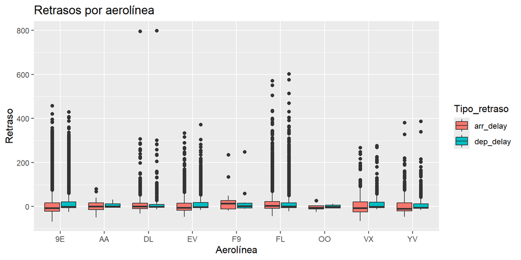

```r
flights %>%
  select(ends_with('delay'), carrier) %>%
  pivot_longer(names_to = 'Tipo_retraso', values_to = 'Values', cols = ends_with('delay')) %>%
  ggplot(aes(x=carrier, y=Values, fill=Tipo_retraso)) +
  geom_boxplot() +
  labs (title = 'Retrasos por aerolínea',
          x = 'Aerolínea',
          y = 'Retraso')
```

- Representa un gráfico de barras que contenga, para cada compañía aérea (`carrier`), el retraso medio de llegadas, de salidas y el retraso global (nueva variable con el promedio del retraso de salida y el retraso de llegadas). El eje $x$ representará la compañía aérea y el eje $y$ el retraso. Las barras de cada tipo de retraso (llegadas, salidas y global) tendrán un color de relleno diferente (tendrás que modificar el data frame con la función `pivot_longer` para crear una nueva variable que indique el tipo de retraso) y se posicionarán una junto a la otra (no apiladas). No olvides añadir etiquetas en los ejes $x$ e $y$.

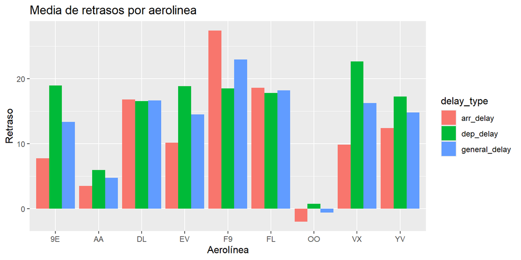

```r
flights %>%
  group_by(carrier) %>%
  summarise(arr_delay = mean(arr_delay, na.rm = TRUE), dep_delay = mean(dep_delay, na.rm = TRUE)) %>%
  mutate(general_delay = (arr_delay + dep_delay) / 2) %>%
  pivot_longer(names_to = "delay_type",
               values_to = "delay",
               cols = c(arr_delay, dep_delay, general_delay)) %>%
  ggplot(aes(x = carrier, y = delay, fill = delay_type)) +
  geom_col(position = 'dodge') + # Para que no sobreponga las columnas
  labs(title = 'Media de retrasos por aerolinea',
       x = 'Aerolínea',
       y = 'Retraso')
```

¿Cuál de las dos representaciones anteriores es más adecuada para visualizar los retrasos?

La representación 2 es más adecuada para visualizar los retrasos, ya que permite comparar los valores entre compañias.

# Entrega de ejercicios

Al finalizar la práctica debes completar el cuestionario de aula virtual. Debes subir a aula virtual el fichero RMarkdown compilado en html o pdf con las soluciones a los ejercicios planteados.